# Review of linear models

Published

24 Sep 2024

Licensed under the [Creative Commons attribution-noncommercial license](http://creativecommons.org/licenses/by-nc/3.0/). Please share & remix noncommercially, mentioning its origin.

```r
## it's nice to include packages at the top
## (and NOT automatically install them)
## try not to carry over packages you don't use
library(faux)
library(brglm2) ## for lizards data
library(ggplot2); theme_set(theme_bw())
## diagnostics
library(performance)
library(DHARMa)
## downstream model evaluation
library(broom)
library(dotwhisker)
library(emmeans)
library(effects)
library(marginaleffects)
library(parameters)
## library(ggeffects)
```

## Why linear models? (Lindeløv 2019)

[figure not shown]

## Basics

- assume $\mathbf y\sim \textrm{Normal}({\mathbf X}\boldsymbol \beta, \sigma)$[^1]
- ${\mathbf X}$ is the *model matrix*, can be anything we want it to be
- the *Gauss-Markov theorem* ([Wikipedia](https://en.wikipedia.org/wiki/Gauss%E2%80%93Markov_theorem)) makes weaker assumptions: $\mathbf y= {\mathbf X}\boldsymbol \beta+ \boldsymbol \epsilon$; as long as $\boldsymbol \epsilon$ is mean-zero, homoscedastic with finite variance, and uncorrelated … then the OLS solution
  $$\hat{\boldsymbol \beta} = ({\mathbf X}^\top {\mathbf X})^{-1} {\mathbf X}^\top \mathbf y$$
  is the BLUE (or MVUE).
- we’ll embrace the assumptions (which are needed for inference!)

## Computation

- matrix decompositions (QR with pivoting; see [here](https://stackoverflow.com/questions/9071020/compute-projection-hat-matrix-via-qr-factorization-svd-and-cholesky-factoriz))
- big problems: `biglm`, `speedglm`, `RcppEigen::fastLm`
  - optimized BLAS, kernel trick, etc.
  - memory vs speed vs robustness …
  - $p$ vs. $n$ vs. many-small-regressions vs. …

## Wald vs LRT

- either approach can be used for tests of *single* parameters, *joint* tests of parameters, or confidence intervals
- Wald makes an additional assumption/approximation (quadratic log-likelihood surface)
  - this assumption is exact for linear models
- Wald may assume either known $\sigma^2$ ($Z$, $\chi^2$ tests) or estimated $\hat \sigma^2$ ($t$, $F$ tests)

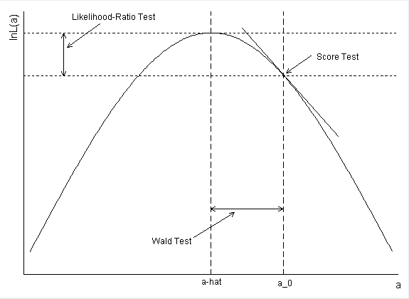

From [OARC stats](https://stats.oarc.ucla.edu/other/mult-pkg/faq/general/faqhow-are-the-likelihood-ratio-wald-and-lagrange-multiplier-score-tests-different-andor-similar/), based on Fox 1977 *Applied regression analysis*

## Model matrices

- model definition converted to ${\mathbf X}$ before we start
- **input variables** vs **predictor variables** (Schielzeth (2010), Gelman and Hill (2006), [CV](https://stats.stackexchange.com/questions/511455/terminology-for-raw-vs-derived-predictor-variables))
  - transformations
  - encoding of categorical variables: **contrasts**
  - interactions
  - basis expansions (e.g. polynomials)

## Wilkinson-Rogers formulas

- Wilkinson and Rogers (1973), updated by Chambers and Hastie (1991, ch. 2)
- operators: `+`, `*`, `:`, `/`, `-`, `^`
- `I()`

## Contrasts

### treatment contrasts

- intercept = baseline, subsequent values are differences
- $\{\beta_0 = \mu_0, \beta_i = \mu_i - \mu_0~\textrm{for}~i>0\}$
- equivalently: $\{\mu_0 = \beta_0, \mu_i = \beta_0 + \beta_i~\textrm{for}~i>0\}$
- **contrast matrix**:

$$\mathbf C\boldsymbol \beta= \left(\begin{array}{cccc}
1 & 0 & 0 & \ldots \\
1 & 1 & 0 & \ldots \\
1 & 0 & 1 & \ldots \\
\vdots & \vdots & \vdots & \ddots
\end{array}
\right)
\left(\begin{array}{c}
\beta_0 \\ \beta_1 \\ \beta_2 \\ \ldots
\end{array}
\right) =
\left(\begin{array}{c}
\mu_1 \\ \mu_2 \\ \mu_3 \\ \ldots
\end{array}\right) \quad .$$

Maybe easier to start from the **inverse** contrast matrix: $\boldsymbol \beta= \mathbf C^{-1} \boldsymbol \mu$.

```r
C <- cbind(1, contr.treatment(3))  ## R omits the intercept by default
solve(C)
```

```
   1 2 3
   1 0 0
2 -1 1 0
3 -1 0 1
```

We have to specify the baseline level (`contr.treatment` uses first level of a factor; `contr.SAS()` uses the last level).

It’s nice when contrasts are *orthogonal*, i.e. all rows are independent $\to \mathbf C^\top \mathbf C$ is diagonal.

### Sum-to-zero contrasts

- intercept is the (unweighted!) average rather than baseline value ($\sum \mu_i/n$)
- other parameters are differences between mean of level $i$ and intercept ($\mu_i - \sum_j \mu_j/n$)
- **last** level is dropped

```r
mfun <- function(C) MASS::fractions(solve(C))
(C <- cbind(1,contr.sum(3)))
```

```
  [,1] [,2] [,3]
1    1    1    0
2    1    0    1
3    1   -1   -1
```

```r
mfun(C)
```

```
     1    2    3
[1,]  1/3  1/3  1/3
[2,]  2/3 -1/3 -1/3
[3,] -1/3  2/3 -1/3
```

### Helmert contrasts

- Weird but orthogonal
- intercept, diff of first two levels, diff of level 3 from 1 & 2, …

```r
(C <- cbind(1,contr.helmert(3)))
```

```
  [,1] [,2] [,3]
1    1   -1   -1
2    1    1   -1
3    1    0    2
```

```r
mfun(C)
```

```
     1    2    3
[1,]  1/3  1/3  1/3
[2,] -1/2  1/2    0
[3,] -1/6 -1/6  1/3
```

### others

- `MASS::contr.sdif()` (successive-differences)
- `contr.poly()` (orthogonal polynomial contrasts)
- custom (e.g., “none” vs “symbiont effect” vs “crabs vs shrimp” vs “two-symbiont effect”) (McKeon et al. (2012); data [here](https://github.com/bbolker/mixedmodels-misc/blob/master/data/culcita.RData))

```r
cc_inv <- matrix(c(1/4,1/4,1/4,1/4,
               1,-1/3,-1/3,-1/3,
               0,1,-1,0,
               0,1/2,1/2,-1),
             byrow=TRUE,
             nrow=4,
             dimnames=list(c("intercept","avg_symb","C.vs.S","twosymb"),
                           c("none","C","S","CS")))
## inverse contrast matrix
MASS::fractions(cc_inv)
```

```
          none C    S    CS
intercept  1/4  1/4  1/4  1/4
avg_symb     1 -1/3 -1/3 -1/3
C.vs.S       0    1   -1    0
twosymb      0  1/2  1/2   -1
```

```r
## contrast matrix
mfun(cc_inv)
```

```
     intercept avg_symb C.vs.S twosymb
none    1       3/4        0      0
C       1      -1/4      1/2    1/3
S       1      -1/4     -1/2    1/3
CS      1      -1/4        0   -2/3
```

## practical issues

- too many ways to set contrasts (`options()`, `contrasts(f) <-`, `lm(..., contrasts = list(...))`
- terrible naming conventions: you can get used to it or use the `faux` package
- OK to fit models and later use `emmeans` to recover desired contrasts (switching linear bases)

```r
mtcars$fcyl <- factor(mtcars$cyl)
lm0 <- lm(mpg ~ fcyl, mtcars)
cn <- function(x) names(coef(x))
cn(lm0)
```

```
[1] "(Intercept)" "fcyl6"       "fcyl8"
```

```r
update(lm0, contrasts = list(fcyl = contr.sum(3))) |> cn()
```

```
[1] "(Intercept)" "fcyl1"       "fcyl2"
```

```r
update(lm0, contrasts = list(fcyl = contr.helmert(3))) |> cn()
```

```
[1] "(Intercept)" "fcyl1"       "fcyl2"
```

## using `faux`

```r
update(lm0, data = transform(mtcars, fcyl = contr_code_sum(fcyl))) |> cn()
```

```
[1] "(Intercept)"      "fcyl.4-intercept" "fcyl.6-intercept"
```

```r
update(lm0, data = transform(mtcars, fcyl = contr_code_helmert(fcyl))) |> cn()
```

```
[1] "(Intercept)" "fcyl.6-4"    "fcyl.8-4.6"
```

## Interactions

- differences in differences
- parameter values of main effects (and $p$ values etc.) depend on contrasts/centering!
- overall model fit ($R^2$, predictions, etc.) is invariant

Lizard data (Schoener (1970), from the `brglm2` package):

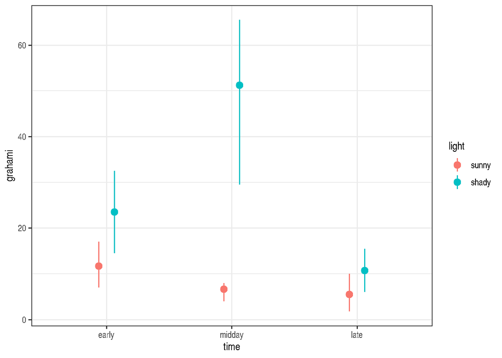

```r
data("lizards", package = "brglm2")
ggplot(lizards, aes(time, grahami, colour = light)) +
    stat_summary(fun.data = mean_cl_boot,
                 position = position_dodge(width = 0.25))
```

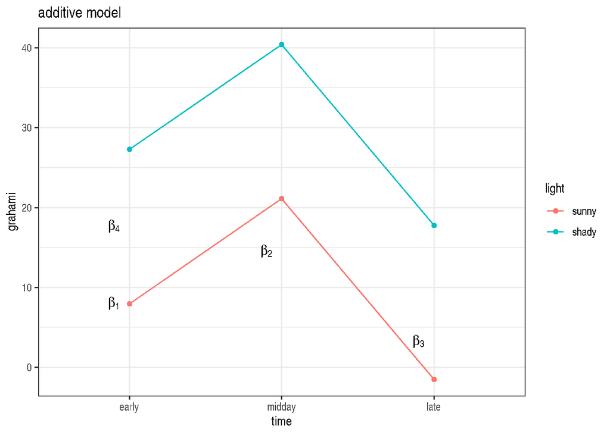

```r
data("lizards", package = "brglm2")
lmTL1 <- lm(grahami~time+light,data=lizards)
pp <- with(lizards,expand.grid(time=levels(time),light=levels(light)))
pp$grahami <- predict(lmTL1,newdata=pp)
cc <- as.list(plyr::rename(coef(lmTL1),c(`(Intercept)`="int")))
labelpos <- with(cc,
  list(x=c(1,2,3,1),xend=c(1,2,3,1),
      y=c(int,int,int,int),
      yend=c(int,int+timemidday,int+timelate,int+lightshady)))
xpos <- -0.1
ggplot(pp,aes(x=time,y=grahami,colour=light))+geom_point()+
  geom_line(aes(group=light))+
  annotate("segment",x=labelpos$x,xend=labelpos$xend,y=labelpos$y,
           yend=labelpos$yend,alpha=0.5,
           arrow=arrow(length = unit(0.3,"cm"),ends="both"))+
  annotate("text",x=with(labelpos,(x+xend)/2)+xpos,y=with(labelpos,(y+yend)/2),
label=paste0("beta[",1:4,"]"),parse=TRUE)+
  annotate("segment",x=labelpos$x[1],xend=labelpos$x[3],y=labelpos$y[1],
           yend=labelpos$y[1],alpha=0.3,lty=2) +
    labs(title = "additive model")
```

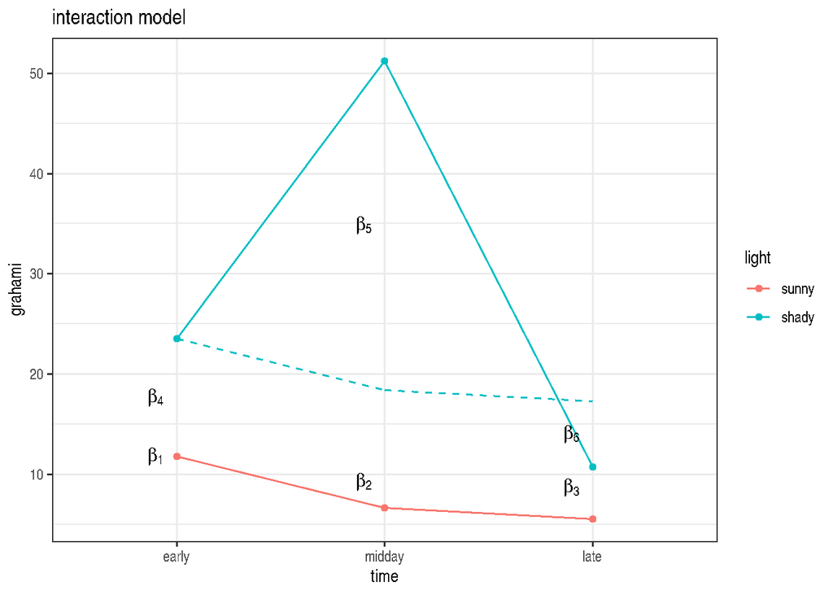

```r
lmTL2 <- lm(grahami~time*light,data=lizards)
gg_color_hue <- function(n) {
  hues = seq(15, 375, length=n+1)
  hcl(h=hues, l=65, c=100)[1:n]
}
pp2 <- pp
pp2$grahami <- predict(lmTL2,newdata=pp)
cc <- as.list(plyr::rename(coef(lmTL2),c(`(Intercept)`="int",
        `timemidday:lightshady`="midshady",`timelate:lightshady`="lateshady")))
labelpos <- with(cc,
  list(x=c(1,2,3,1,2,3),xend=c(1,2,3,1,2,3),
      y=c(int,int,int,int,int+lightshady+timemidday,int+lightshady+timelate),
      yend=c(int,int+timemidday,int+timelate,int+lightshady,
             int+timemidday+lightshady+midshady,int+timelate+lightshady+lateshady)))
xpos <- -0.1
ggplot(pp2,aes(x=time,y=grahami,colour=light))+geom_point()+
  geom_line(aes(group=light))+
  annotate("segment",x=1:2,xend=2:3,
           y=with(cc,c(int+lightshady,int+timemidday+lightshady)),
           yend=with(cc,c(int+timemidday+lightshady,int+timelate+lightshady)),
           colour=gg_color_hue(2)[2],lty=2)+
  annotate("segment",x=labelpos$x,xend=labelpos$xend,y=labelpos$y,
           yend=labelpos$yend,alpha=0.5) +
           ## arrow=arrow(length = unit(0.3,"cm"),ends="both"))+
  annotate("text",x=with(labelpos,(x+xend)/2)+xpos,y=with(labelpos,(y+yend)/2),
label=paste0("beta[",1:6,"]"),parse=TRUE)+
  annotate("segment",x=rep(labelpos$x[1],2),
                     xend=rep(labelpos$x[3],2),
                     y=labelpos$yend[c(1,4)],
           yend=labelpos$yend[c(1,4)],alpha=0.3,lty=2) +
    labs(title = "interaction model")
```

## Marginality

- Venables (1998)
- ‘type (X) sums of squares’
- scaling and centering (Schielzeth 2010) alleviates many problems; sum-to-zero contrasts (weighted or unweighted?)

## Making life easier with `emmeans`

# Model interpretation, visualization, testing

## Diagnostics

- linearity > heteroscedasticity, outliers > normality
- upstream problems can induce downstream problems first
- universal plots are universal, but less interpretable than problem-specific exploration (try to identify problematic predictors/groups/etc.)

## Graphical diagnostics

- base R: `stats::plot.lm()`
- `performance::check_model()`
- `DHARMa` (`simulateResiduals(., plot = TRUE)`)
  - (`plotResiduals(simout, form = pred_var)`)
- `broom::augment()` + plot-your-own (`ggplot2`)

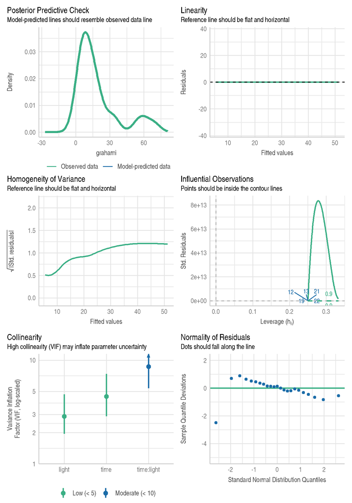

```r
performance::check_model(lmTL2)
```

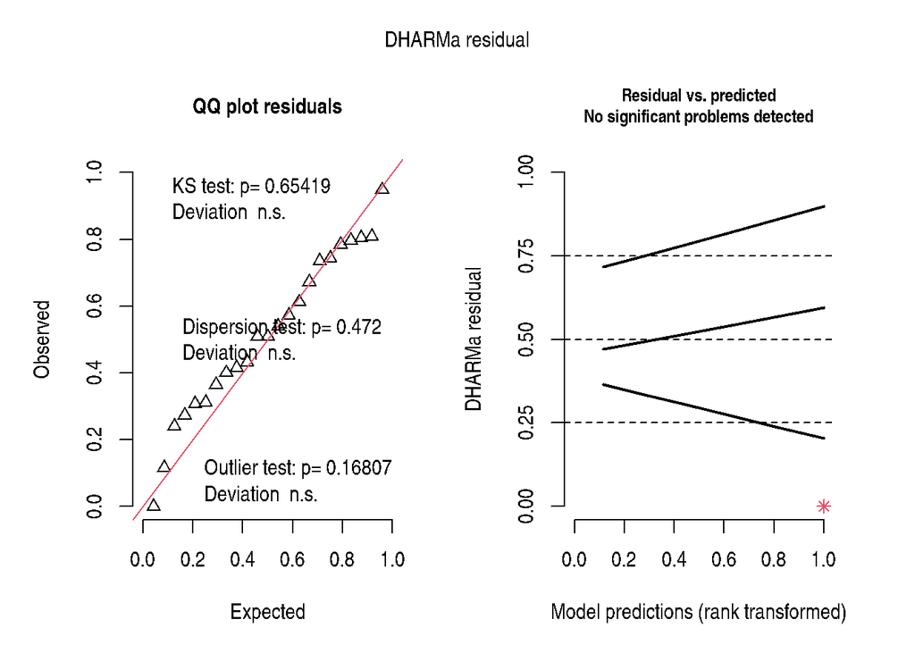

```r
ss <- simulateResiduals(lmTL2)
plot(ss)
```

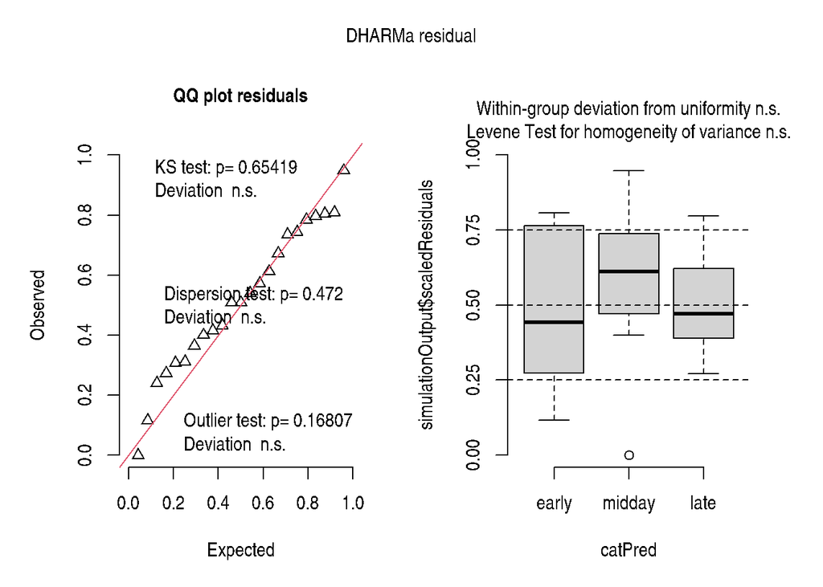

```r
plot(ss, form = lizards$time)
```

## Solutions to problems

- **nonlinearity**: transformation, add covariates (??), add interactions, add polynomial terms etc.
- **outliers**: drop values (report both!), use robust regression
- **heteroscedasticity**: transformation, model dispersion explicitly, GLMs
- **non-Normality**: transformation, GLMs

## Transformation

- May do too much at once (GLMs and GAMs allow more flexibility)
- Log-transformation is often interpretable and solves problems
- Transforming boundary values (e.g. $\log(0)$) is problematic
- **Box-Cox transformations**: $y \to \frac{y^\lambda - 1}{\lambda}$ (include Jacobian term $\textrm{GM}^{\lambda-1}$ in denominator to keep log-likelihood comparable)
  - flexible
  - in practice people often use ‘round numbers’: $\lambda = 0$ (log), 1/2 (square root), etc.
  - `MASS::boxcox()`
  - hard to interpret!

## Example

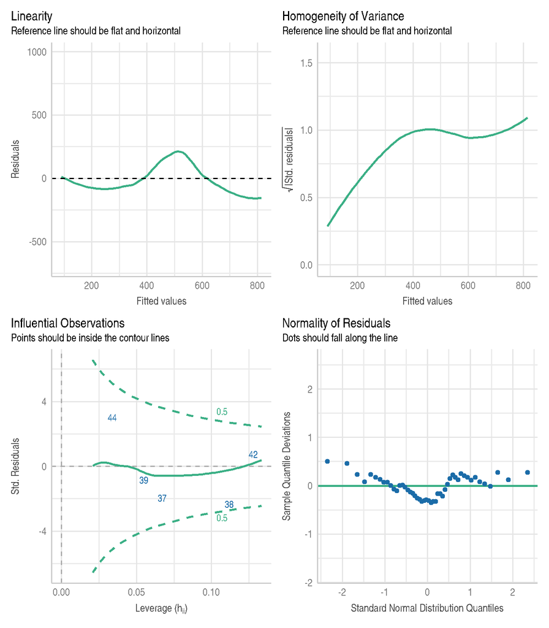

```r
library(faraway)
m1 <- lm(perm ~ area, rock)
performance::check_model(m1, check = c("linearity", "homogeneity", "outliers", "qq"))
```

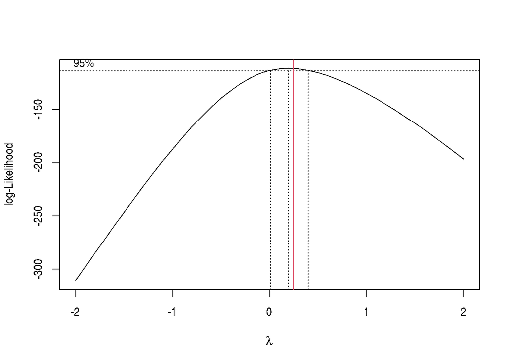

```r
m <- MASS::boxcox(m1, interp = FALSE)
abline(v=1/4, col = 2)
```

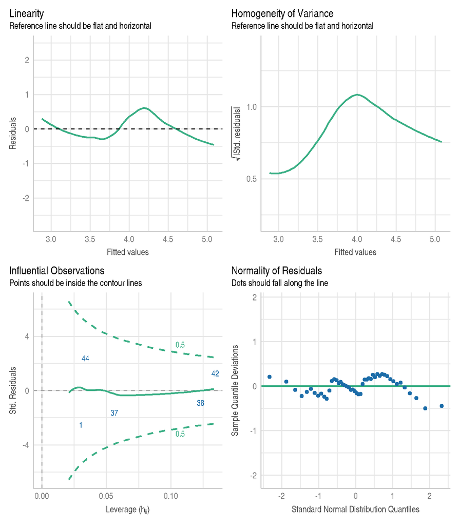

```r
m2 <- update(m1, perm^(1/4) ~ .)
performance::check_model(m2, check = c("linearity", "homogeneity", "outliers", "qq"))
```

When we transform we have to add the logs of the *Jacobian* of the transform to the log-likelihood, or subtract $\sum\log(J_i)$ from the negative log-likelihood (Cranmer 2020). For example, if we log-transform,
$$\begin{split}
\sum\log(J(y_i)) & =\sum\log\left(\partial(\log(y_i))/\partial y\right) \\
& = \sum \log(1/y_i) \\
& = -\sum\log y_i.
\end{split}$$
In this case $\sum\log(J(y_i))=\sum \log\left((1/4) P^{-3/4}\right) = -N \log 4 -3/4 \sum\log(P)$:

Check:

```r
logJ <- -(nrow(rock)*log(4)  + 3/4*sum(log(rock$perm)))
lm2 <- logLik(m2) + logJ
lm1 <- logLik(m1)
lm2-lm1
```

```
'log Lik.' 23.3844 (df=3)
```

```r
## difference from Box-Cox sequence
max(m$y)-m$y[m$x==1]
```

```
[1] 23.52213
```

## Reminder about parameter scaling

- Schielzeth (2010), Gelman (2008)
- centering ensures no problems with marginality (analogous to sum-to-zero contrasts)
- scaling predictors gives coefficients equal units (analogous to Cohen’s $d$)
- scaling response makes coefficients *standardized partial regression coefficients* (equal to partial correlation coefficients if predictors are independent)
- scaling by 2 SD makes coefficients equivalent to those from balanced binary predictors
- scaling inputs or scaling predictors?

## What about correlated predictors?

- Can compute *variance inflation factors* (VIFs)
- Dropping correlated factors is dubious: Graham (2003), Dormann et al. (2012), Morrissey and Ruxton (2018), Vanhove (2021)
- perfect collinearity gets handled automatically by R’s pivoting, but may want to change contrasts/model setup

```r
summary(lmTL2)
```

```
Call:
lm(formula = grahami ~ time * light, data = lizards)

Residuals:
    Min      1Q  Median      3Q     Max
-30.250  -4.125   1.250   6.875  17.750

Coefficients:
                      Estimate Std. Error t value Pr(>|t|)
(Intercept)             11.750      5.375   2.186  0.04311 *
timemidday              -5.083      8.211  -0.619  0.54408
timelate                -6.250      7.602  -0.822  0.42238
lightshady              11.750      7.602   1.546  0.14061
timemidday:lightshady   32.833     11.190   2.934  0.00927 **
timelate:lightshady     -6.500     10.751  -0.605  0.55343
---
Signif. codes:  0 '***' 0.001 '**' 0.01 '*' 0.05 '.' 0.1 ' ' 1

Residual standard error: 10.75 on 17 degrees of freedom
Multiple R-squared:  0.7504,    Adjusted R-squared:  0.677
F-statistic: 10.22 on 5 and 17 DF,  p-value: 0.0001179
```

```r
broom::tidy(lmTL2)
```

```
# A tibble: 6 × 5
  term                  estimate std.error statistic p.value
  <chr>                    <dbl>     <dbl>     <dbl>   <dbl>
1 (Intercept)              11.8       5.38     2.19  0.0431
2 timemidday               -5.08      8.21    -0.619 0.544
3 timelate                 -6.25      7.60    -0.822 0.422
4 lightshady               11.7       7.60     1.55  0.141
5 timemidday:lightshady    32.8      11.2      2.93  0.00927
6 timelate:lightshady      -6.5      10.8     -0.605 0.553
```

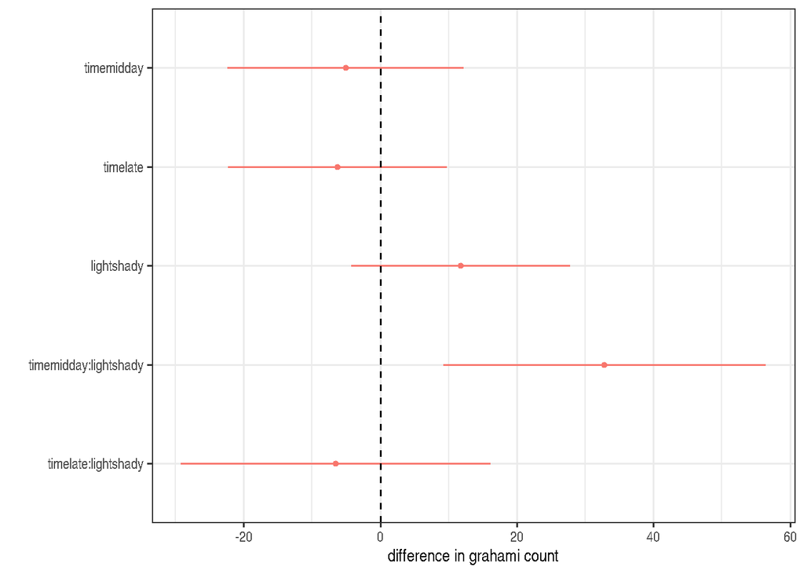

```r
## automatically drop intercept; optional by_2sd argument
dotwhisker::dwplot(lmTL2) + geom_vline(xintercept = 0, lty = 2) +
    labs(x="difference in grahami count")
```

## Interpretation and testing

- Look at coefficient tables: `summary()` or `coef(summary())`
- model comparison: `drop1()`, `anova()`, `car::Anova()`
- coefficient *plots*: `broom` + `ggplot2`, `dotwhisker`

## Downstream methods

- plot predictions **with data**
- partial residuals plots (e.g. [remef package](https://github.com/hohenstein/remef))
- prediction, effects plots
- uncertainty of predictions
- `emmeans`, `marginaleffects`, `effects`, `sjPlot` …

## References

Chambers, J. M., and T. J. Hastie, eds. 1991. *Statistical Models in S*. 1st ed. Chapman & Hall/CRC.

Cranmer, Kyle. 2020. “Transformation Properties of the Likelihood and Posterior.” https://cranmer.github.io/stats-ds-book/distributions/invariance-of-likelihood-to-reparameterizaton.html.

Dormann, Carsten F., Jane Elith, Sven Bacher, Carsten Buchmann, Gudrun Carl, Gabriel Carré, Jaime R. García Marquéz, et al. 2012. “Collinearity: A Review of Methods to Deal with It and a Simulation Study Evaluating Their Performance.” *Ecography*, no–. https://doi.org/10.1111/j.1600-0587.2012.07348.x.

Gelman, Andrew. 2008. “Scaling Regression Inputs by Dividing by Two Standard Deviations.” *Statistics in Medicine* 27 (15): 2865–73. https://doi.org/10.1002/sim.3107.

Gelman, Andrew, and Jennifer Hill. 2006. *Data Analysis Using Regression and Multilevel/Hierarchical Models*. Cambridge, England: Cambridge University Press.

Graham, Michael H. 2003. “Confronting Multicollinearity in Ecological Multiple Regression.” *Ecology* 84 (11): 2809–15. https://doi.org/10.1890/02-3114.

Lindeløv, Jonas Kristoffer. 2019. “Common Statistical Tests Are Linear Models (or: How to Teach Stats).” https://lindeloev.github.io/tests-as-linear/.

McKeon, C., Adrian Stier, Shelby McIlroy, and Benjamin Bolker. 2012. “Multiple Defender Effects: Synergistic Coral Defense by Mutualist Crustaceans.” *Oecologia* 169 (4): 1095–1103. https://doi.org/10.1007/s00442-012-2275-2.

Morrissey, Michael B., and Graeme D. Ruxton. 2018. “Multiple Regression Is Not Multiple Regressions: The Meaning of Multiple Regression and the Non-Problem of Collinearity.” *Philosophy, Theory, and Practice in Biology* 10 (3).

Schielzeth, Holger. 2010. “Simple Means to Improve the Interpretability of Regression Coefficients: Interpretation of Regression Coefficients.” *Methods in Ecology and Evolution* 1 (2): 103–13. https://doi.org/10.1111/j.2041-210X.2010.00012.x.

Schoener, Thomas W. 1970. “Nonsynchronous Spatial Overlap of Lizards in Patchy Habitats.” *Ecology* 51 (3): 408–18. https://doi.org/10.2307/1935376.

Vanhove, Jan. 2021. “Collinearity Isn’t a Disease That Needs Curing.” *Meta-Psychology* 5 (April). https://doi.org/10.15626/MP.2021.2548.

Venables, W. N. 1998. “Exegeses on Linear Models.” In. 1998 International S-PLUS User Conference. Washington, DC. http://www.stats.ox.ac.uk/pub/MASS3/Exegeses.pdf.

Wilkinson, G. N., and C. E. Rogers. 1973. “Symbolic Description of Factorial Models for Analysis of Variance.” *Journal of the Royal Statistical Society. Series C (Applied Statistics)* 22 (3): 392–99. https://doi.org/10.2307/2346786.

## Footnotes

[^1]: Notation-abuse warning …